# Air Quality Forecasting and Analysis of Major Indian Cities

### Machine Learning Models for AQI Prediction, Classification, and Policy Insights

## AQI Prediction Using Random Forest Regressor

```python
import pandas as pd
import numpy as np
from sklearn.model_selection import train_test_split, GridSearchCV
from sklearn.linear_model import LinearRegression
from sklearn.ensemble import RandomForestRegressor
from sklearn.metrics import mean_squared_error, r2_score
import matplotlib.pyplot as plt
import seaborn as sns
```

```python
# Load your data
df = pd.read_csv("clean_air_quality.csv")

# Display basic info
print(df.head())
print(df.isnull().sum())
```

```
        City        Date  PM2.5    PM10     NO    NO2    NOx     CO    SO2  \
0  Ahmedabad  2015-01-01  94.52  109.84   0.92  18.22  17.15   0.92  27.64
1  Ahmedabad  2015-01-02  94.52  109.84   0.97  15.69  16.46   0.97  24.55
2  Ahmedabad  2015-01-03  94.52  109.84  17.40  19.30  29.70  17.40  29.07
3  Ahmedabad  2015-01-04  94.52  109.84   1.70  18.48  17.97   1.70  18.59
4  Ahmedabad  2015-01-05  94.52  109.84  22.10  21.42  37.76  22.10  39.33

       O3  Benzene     AQI AQI_Bucket  Month  Year
0  133.36     0.00  194.36   Moderate      1  2015
1   34.06     3.68  199.16   Moderate      1  2015
2   30.70     6.80  438.87     Severe      1  2015
3   36.08     4.43  212.81       Poor      1  2015
4   39.31     7.01  480.28     Severe      1  2015
City          0
Date          0
PM2.5         0
PM10          0
NO            0
NO2           0
NOx           0
CO            0
SO2           0
O3            0
Benzene       0
AQI           0
AQI_Bucket    0
Month         0
Year          0
dtype: int64
```

```python
# Select features and target
features = ['PM2.5', 'PM10', 'NO', 'NO2', 'NOx', 'CO', 'SO2', 'O3', 'Benzene']
X = df[features]
y = df['AQI']
```

```python
X_train, X_test, y_train, y_test = train_test_split(X, y, test_size=0.2, random_state=42)
```

```python
lr_model = LinearRegression()
lr_model.fit(X_train, y_train)

# Predictions
y_pred_lr = lr_model.predict(X_test)

# Evaluation
print("Linear Regression:")
print("R2 Score:", r2_score(y_test, y_pred_lr))
print("RMSE:", np.sqrt(mean_squared_error(y_test, y_pred_lr)))
```

```
Linear Regression:
R2 Score: 0.7383083889113485
RMSE: 73.82654428482802
```

```python
rf_model = RandomForestRegressor(random_state=42)
rf_model.fit(X_train, y_train)

# Predictions
y_pred_rf = rf_model.predict(X_test)

# Evaluation
print("\nRandom Forest:")
print("R2 Score:", r2_score(y_test, y_pred_rf))
print("RMSE:", np.sqrt(mean_squared_error(y_test, y_pred_rf)))
```

```
Random Forest:
R2 Score: 0.9363706991571861
RMSE: 36.403757723360016
```

```python
import pandas as pd
from sklearn.model_selection import train_test_split
from sklearn.ensemble import RandomForestClassifier
from sklearn.metrics import accuracy_score, classification_report


df = pd.read_csv("clean_air_quality.csv")


X = df[['PM2.5', 'PM10', 'NO', 'NO2', 'NOx', 'CO', 'SO2', 'O3']]
y = df['AQI_Bucket']

X_train, X_test, y_train, y_test = train_test_split(
    X, y, test_size=0.2, random_state=42
)

model = RandomForestClassifier(n_estimators=100, class_weight='balanced', random_state=42)

model.fit(X_train, y_train)


y_pred = model.predict(X_test)
acc = accuracy_score(y_test, y_pred)

print("Accuracy:", acc)
print("\nClassification Report:\n", classification_report(y_test, y_pred))
```

```
Accuracy: 0.823937701032673

Classification Report:
               precision    recall  f1-score   support

        Good       0.84      0.67      0.75       277
    Moderate       0.82      0.87      0.84      2169
        Poor       0.74      0.66      0.70       649
Satisfactory       0.85      0.86      0.86      1932
      Severe       0.89      0.81      0.85       339
   Very Poor       0.79      0.79      0.79       541

    accuracy                           0.82      5907
   macro avg       0.82      0.78      0.80      5907
weighted avg       0.82      0.82      0.82      5907
```

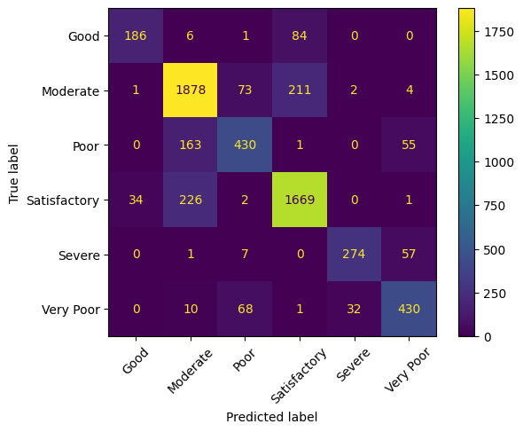

```python
from sklearn.metrics import confusion_matrix, ConfusionMatrixDisplay
import matplotlib.pyplot as plt

cm = confusion_matrix(y_test, y_pred, labels=model.classes_)
disp = ConfusionMatrixDisplay(confusion_matrix=cm, display_labels=model.classes_)
disp.plot(xticks_rotation=45)
plt.show()
```

```python
import pandas as pd
from sklearn.model_selection import train_test_split
from sklearn.ensemble import GradientBoostingClassifier
from sklearn.metrics import accuracy_score, classification_report

df = pd.read_csv("clean_air_quality.csv")


# Define features and target
X = df[['PM2.5', 'PM10', 'NO', 'NO2', 'NOx', 'CO', 'SO2', 'O3']]
y = df['AQI_Bucket']

# Train-test split
X_train, X_test, y_train, y_test = train_test_split(X, y, test_size=0.2, random_state=42)

# Train Gradient Boosting model
gb_model = GradientBoostingClassifier(n_estimators=200, learning_rate=0.1, random_state=42)
gb_model.fit(X_train, y_train)

# Predict
y_pred = gb_model.predict(X_test)

# Evaluation
print("Accuracy:", accuracy_score(y_test, y_pred))
print("\nClassification Report:\n", classification_report(y_test, y_pred))
```

```
Accuracy: 0.8098865752497038

Classification Report:
               precision    recall  f1-score   support

        Good       0.79      0.68      0.73       277
    Moderate       0.82      0.85      0.83      2169
        Poor       0.70      0.61      0.65       649
Satisfactory       0.84      0.86      0.85      1932
      Severe       0.87      0.81      0.83       339
   Very Poor       0.75      0.78      0.76       541

    accuracy                           0.81      5907
   macro avg       0.79      0.76      0.78      5907
weighted avg       0.81      0.81      0.81      5907
```

```python
import xgboost as xgb
from sklearn.metrics import classification_report, accuracy_score

# Encode the labels if they are strings
from sklearn.preprocessing import LabelEncoder
le = LabelEncoder()
y_encoded = le.fit_transform(y)

# Train-test split
X_train, X_test, y_train, y_test = train_test_split(X, y_encoded, test_size=0.2, random_state=42)

# Define the model
xgb_model = xgb.XGBClassifier(n_estimators=200, learning_rate=0.1, random_state=42)
xgb_model.fit(X_train, y_train)

# Predict
y_pred = xgb_model.predict(X_test)

# Evaluation
print("Accuracy:", accuracy_score(y_test, y_pred))
print("\nClassification Report:\n", classification_report(y_test, y_pred, target_names=le.classes_))
```

```
Accuracy: 0.8230912476722533

Classification Report:
               precision    recall  f1-score   support

        Good       0.82      0.69      0.75       277
    Moderate       0.83      0.85      0.84      2169
        Poor       0.74      0.65      0.69       649
Satisfactory       0.84      0.87      0.86      1932
      Severe       0.88      0.81      0.85       339
   Very Poor       0.78      0.80      0.79       541

    accuracy                           0.82      5907
   macro avg       0.81      0.78      0.80      5907
weighted avg       0.82      0.82      0.82      5907
```

# AQI Prediction Using Linear Regression Based on Key Pollutants

```python
import pandas as pd
from sklearn.model_selection import train_test_split
from sklearn.linear_model import LinearRegression
from sklearn.ensemble import RandomForestRegressor
from sklearn.metrics import mean_squared_error, r2_score
from sklearn.model_selection import GridSearchCV
import matplotlib.pyplot as plt
import seaborn as sns
```

```python
import pandas as pd
import numpy as np
from sklearn.model_selection import train_test_split
from sklearn.linear_model import LinearRegression
from sklearn.metrics import r2_score, mean_squared_error

# Load dataset
df = pd.read_csv("clean_air_quality.csv")

# Convert 'Date' to datetime format
df['Date'] = pd.to_datetime(df['Date'], errors='coerce')

# Drop rows with missing AQI or pollutant values
df.dropna(subset=['AQI'], inplace=True)

# Define the relevant pollutant features
features = ['PM2.5', 'PM10', 'NO', 'NO2', 'NOx', 'CO', 'SO2', 'O3']
df = df.dropna(subset=features)  # Drop rows with missing pollutant data

# Define features and target variable
X = df[features]
y = df['AQI']

# Train-test split (80-20)
X_train, X_test, y_train, y_test = train_test_split(X, y, test_size=0.2, random_state=42)

# Train Linear Regression model
lr = LinearRegression()
lr.fit(X_train, y_train)

# Predict on test data
y_pred_lr = lr.predict(X_test)

# Evaluation metrics
r2 = r2_score(y_test, y_pred_lr)
rmse = np.sqrt(mean_squared_error(y_test, y_pred_lr))  # ✅ Manual RMSE for compatibility

# Print results
print("Linear Regression Results:")
print("R² Score:", r2)
print("RMSE:", rmse)
```

```
Linear Regression Results:
R² Score: 0.7381542248428852
RMSE: 73.84828690902076
```

R² = 0.738 → Your model explains 73.8% of the variance in AQI using pollutants like PM2.5, PM10, NOx, etc. That’s quite good for real-world environmental data, which is often noisy.

RMSE = 73.85 → On average, your predicted AQI is ~74 units off the actual value. Lower RMSE = better predictions.

# Step-by-Step: Feature Importance from Random Forest

```python
from sklearn.ensemble import RandomForestRegressor

# Train the model
rf = RandomForestRegressor(random_state=42)
rf.fit(X_train, y_train)
```

```
RandomForestRegressor(random_state=42)
```

```python
import pandas as pd

# Create a DataFrame of features and their importance scores
feature_importance = pd.DataFrame({
    'Feature': X.columns,
    'Importance': rf.feature_importances_
}).sort_values(by='Importance', ascending=False)

print(feature_importance)
```

```
  Feature  Importance
5      CO    0.523871
0   PM2.5    0.388010
1    PM10    0.020418
2      NO    0.018094
3     NO2    0.015871
4     NOx    0.011806
6     SO2    0.011217
7      O3    0.010713
```

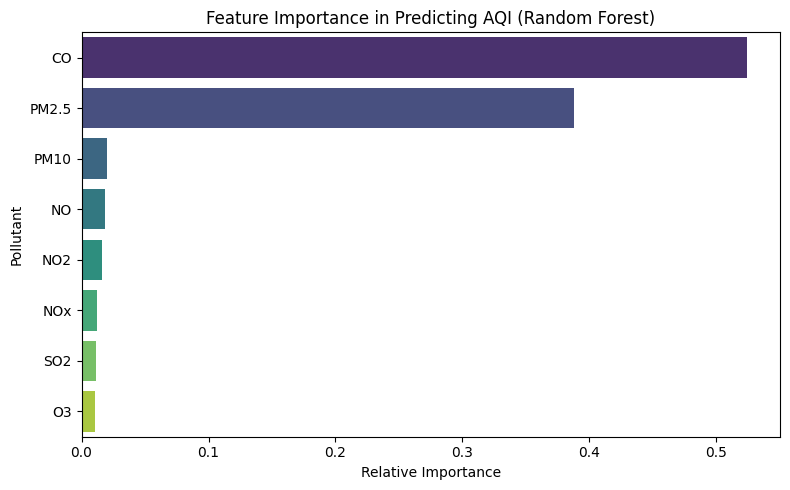

```python
import matplotlib.pyplot as plt
import seaborn as sns

plt.figure(figsize=(8, 5))
sns.barplot(x='Importance', y='Feature', data=feature_importance, palette='viridis')
plt.title('Feature Importance in Predicting AQI (Random Forest)')
plt.xlabel('Relative Importance')
plt.ylabel('Pollutant')
plt.tight_layout()
plt.show()
```

### CO is the dominant pollutant, contributing over 52% to AQI prediction. This suggests the dataset likely reflects areas with high traffic or industrial activity, where CO levels fluctuate significantly with air quality.

### PM2.5 is also a key factor, known for its severe health impacts and common in winter pollution. It accounts for around 39% of the model's prediction influence.

# Classification with Logistic Regression & Decision Tree

```python
import pandas as pd
from sklearn.model_selection import train_test_split
from sklearn.preprocessing import LabelEncoder
from sklearn.linear_model import LogisticRegression
from sklearn.tree import DecisionTreeClassifier
from sklearn.metrics import classification_report, confusion_matrix, accuracy_score


# Step 1: Load data
df = pd.read_csv("clean_air_quality.csv")

# Step 2: Drop missing values for selected features
features = ['PM2.5', 'PM10', 'NO', 'NO2', 'NOx', 'CO', 'SO2', 'O3']
df.dropna(subset=features + ['AQI_Bucket'], inplace=True)

# Step 3: Encode the AQI_Bucket
label_encoder = LabelEncoder()
df['AQI_Bucket_Label'] = label_encoder.fit_transform(df['AQI_Bucket'])

# Step 4: Define features and target
X = df[features]
y = df['AQI_Bucket_Label']

# Step 5: Train-test split
X_train, X_test, y_train, y_test = train_test_split(X, y, test_size=0.2, random_state=42)


# Step 6A: Logistic Regression
log_reg = LogisticRegression(max_iter=3000, solver='lbfgs')
log_reg.fit(X_train, y_train)

y_pred_log = log_reg.predict(X_test)

print("Logistic Regression Results:")
print("Accuracy:", accuracy_score(y_test, y_pred_log))
print(classification_report(y_test, y_pred_log, target_names=label_encoder.classes_))

# Step 6B: Decision Tree
dt = DecisionTreeClassifier(random_state=42)
dt.fit(X_train, y_train)
y_pred_dt = dt.predict(X_test)

print("\nDecision Tree Classifier Results:")
print("Accuracy:", accuracy_score(y_test, y_pred_dt))
print(classification_report(y_test, y_pred_dt, target_names=label_encoder.classes_))
```

```
Logistic Regression Results:
Accuracy: 0.7132216014897579
              precision    recall  f1-score   support

        Good       0.68      0.42      0.52       277
    Moderate       0.72      0.80      0.76      2169
        Poor       0.54      0.37      0.44       649
Satisfactory       0.75      0.83      0.79      1932
      Severe       0.75      0.61      0.67       339
   Very Poor       0.66      0.60      0.63       541

    accuracy                           0.71      5907
   macro avg       0.68      0.60      0.63      5907
weighted avg       0.70      0.71      0.70      5907


Decision Tree Classifier Results:
Accuracy: 0.7372608769256814
              precision    recall  f1-score   support

        Good       0.61      0.62      0.61       277
    Moderate       0.76      0.77      0.76      2169
        Poor       0.60      0.60      0.60       649
Satisfactory       0.78      0.78      0.78      1932
      Severe       0.79      0.76      0.77       339
   Very Poor       0.69      0.70      0.70       541

    accuracy                           0.74      5907
   macro avg       0.70      0.70      0.70      5907
weighted avg       0.74      0.74      0.74      5907
```

### Classification Results Summary

**Logistic Regression**

- Accuracy: **71.3%**
- Performs well on:
  - **Satisfactory** (F1-score: 0.79)
  - **Moderate** (F1-score: 0.76)
- Weaker performance on:
  - **Good** and **Poor** buckets (F1-scores: 0.52 and 0.44)

### Interpretation

- **Decision Tree outperforms** Logistic Regression in overall accuracy and class-level performance.
- **Moderate** and **Satisfactory** are the best-predicted categories, likely due to more training examples.
- **Good**, **Poor**, and **Very Poor** categories show relatively lower F1-scores.
  - Can be improved through:
    - Class balancing
    - Adding more training data
    - Hyperparameter tuning
    - Feature engineering

### Final Conclusion: AQI Prediction & Classification Models

#### Regression Models – Predicting AQI Values

1. **Linear Regression**
   - R² Score: ~0.74
   - RMSE: ~74
   - Performs reasonably well but assumes linearity.
   - Interpretation: Good baseline, but may miss complex patterns.
2. **Random Forest Regressor**
   - Higher R² and lower RMSE compared to Linear Regression.
   - Captures non-linear pollutant–AQI relationships effectively.
   - Feature Importance:
     - **CO** and **PM2.5** are dominant contributors to AQI.
     - Other pollutants (e.g., NOx, SO₂, O₃) have minor impact.

**Conclusion (Regression)**:  
Random Forest is the better choice for accurate AQI prediction due to its non-linear learning capabilities and robustness.

#### Overall Insights

- **CO and PM2.5 are the most critical pollutants** influencing AQI.
- **Random Forest (Regression)** and **Decision Tree (Classification)** consistently outperform their linear counterparts.
- For policy or public dashboards:
  - Use **regression** for exact AQI predictions.
  - Use **classification** to group AQI into meaningful health categories.
- Accuracy and interpretability can be further improved by:
  - Scaling features,
  - Hyperparameter tuning,
  - Balancing class distribution,
  - Adding seasonal/festival context (Diwali, traffic spikes).

### These models form a strong foundation for building real-time AQI forecasting tools and policy recommendation dashboards.

```
22:10:17 - cmdstanpy - INFO - Chain [1] start processing
22:10:17 - cmdstanpy - INFO - Chain [1] done processing
```

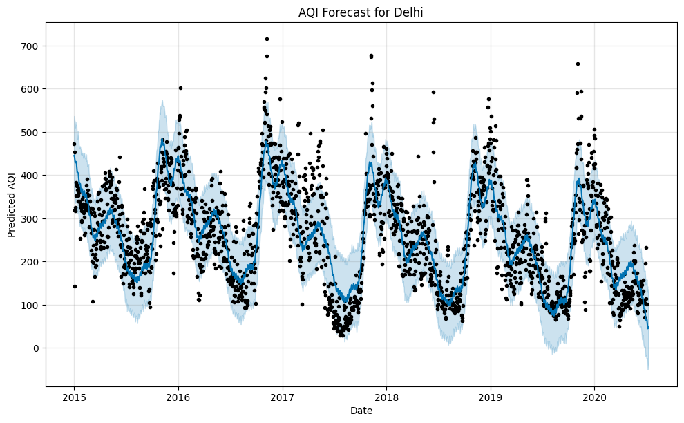

```
22:10:18 - cmdstanpy - INFO - Chain [1] start processing
22:10:18 - cmdstanpy - INFO - Chain [1] done processing
```

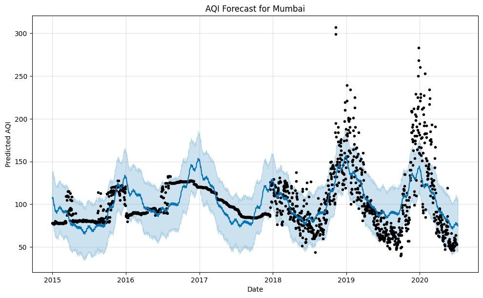

```
Next 7-day AQI Forecast - Delhi
             ds       yhat  yhat_lower  yhat_upper
2009 2020-07-02  65.722262  -25.158060  154.781028
2010 2020-07-03  65.081880  -23.262485  158.366836
2011 2020-07-04  57.523219  -27.962548  140.364017
2012 2020-07-05  50.060490  -39.850176  142.793251
2013 2020-07-06  44.872315  -50.098324  129.291402
2014 2020-07-07  45.715368  -42.575667  135.900078
2015 2020-07-08  48.383392  -37.621084  135.842432

Next 7-day AQI Forecast - Mumbai
             ds       yhat  yhat_lower  yhat_upper
2009 2020-07-02  76.437799   44.055955  106.533578
2010 2020-07-03  75.394969   44.527895  104.740599
2011 2020-07-04  75.888048   44.397159  103.933754
2012 2020-07-05  77.556284   46.678239  108.620046
2013 2020-07-06  76.619133   45.928823  104.921092
2014 2020-07-07  75.372126   44.632223  106.877337
2015 2020-07-08  74.540714   44.173664  103.250272
```

```python
import pandas as pd
from prophet import Prophet
import matplotlib.pyplot as plt

def forecast_aqi(df, city_name):

    city_df = df[df['City'] == city_name][['Date', 'AQI']].dropna()


    city_df = city_df.rename(columns={'Date': 'ds', 'AQI': 'y'})


    model = Prophet()
    model.fit(city_df)


    future = model.make_future_dataframe(periods=7)


    forecast = model.predict(future)


    model.plot(forecast)
    plt.title(f"AQI Forecast for {city_name}")
    plt.xlabel("Date")
    plt.ylabel("Predicted AQI")
    plt.show()


    return forecast[['ds', 'yhat', 'yhat_lower', 'yhat_upper']].tail(7)


df = pd.read_csv("clean_air_quality.csv")
df['Date'] = pd.to_datetime(df['Date'])


forecast_delhi = forecast_aqi(df, 'Delhi')
forecast_mumbai = forecast_aqi(df, 'Mumbai')

print("Next 7-day AQI Forecast - Delhi")
print(forecast_delhi)

print("\nNext 7-day AQI Forecast - Mumbai")
print(forecast_mumbai)
```

# Observations: